# ProJIVE and CJIVE

# Short Introudction

## Input Parameters to Simulate Data

Input parameters for generating data include the following quantities: $n$ - number of subjects; $p_k$ - number of features in $k^{th}$ data block ($k=1,\dots,K$); $r_J$ - joint rank; $r_{Ik}$ - individual rank for $k^{th}$ data block; $R_{Jk}^2$ - proportion of total variation n $k^{th}$ data block attributable to the joint signal; $R_{Ik}^2$ - proportion of total variation n $k^{th}$ data block attributable to it’s individual signal. Note: the last parameters described were proportions and therefore require $R_{Jk}^2 + R_{Ik}^2 < 1$ for each $k$. The user may also set a ‘seed number’ to ensure reproducibility. We use seed number = 0.

```r
# Sample size
n = 500

# Number of features per block (input as a vector)
p1 = 30
p2 = 50

# Joint Rank
r.J = 1

# Individual rank for each block (input as a vector)
r.I1 = 2
r.I2 = 2

# Proportions of joint variation explained (input as a vector)
JntVarEx1 = 0.05
JntVarEx2 = 0.5

# Proportions of individual variation explained (input as a vector)
IndVarEx1 = 0.25
IndVarEx2 = 0.25
```

### The ’GenerateToyData` Function

In addition to the input parameters defined above, the function “GenerateToyData” has the following parameters: ‘equal.eig’ - logical (TRUE/FALSE), which allows the user to specify whether components within a data-blocks joint (or individual) signal should be equally waited. The default is FALSE

‘JntVarAdj’ - logical (TRUE/FALSE): Specify whether signal matrices should be weighted to achieve the desired proportions of variation attributable to the joint signal

‘SVD.plots’ - logical (TRUE/FALSE): Should plots of signal matrix singular values be produced to verify ranks?

‘Error’ - logical (TRUE/FALSE): Should the data be noise-contaminated?

‘print.cor’ - logical (TRUE/FALSE), Print the correlation matrix for the scores? (Allows one to assess orthoganility between scores/compnents)

‘Loads’ - char: Toy data can be generated with loadings from ‘Gaussian’, ‘Rademacher’, or ‘Double_Exp’ (double exponential) distributions. Loadings can also be fixed at binary (0/1) values assigned to half of the variables with keyword ‘Fixed’

‘Scores’ - char: Joint subject scores can be randomly generated from ‘Gaussian’, ‘Binomial’, or ‘Gaussian_Mixture’ distributions. The last refers to a mixture of Gaussians with unit variance, where $20\%$ have mean $-4$, $50\%$ have mean $0$, and $30\%$ have mean $4$. In all cases individual scores are standard Gaussian

```
## [1] "Generating Scores from Gaussian distributions and Loadings from Rademacher distributions."
## [1] "The correlation between subject scores is given by"
##                  Jnt Score 1 Indiv X1 Score 1 Indiv X1 Score 2 Indiv X2 Score 1
## Jnt Score 1           1.0000          -0.0233          -0.0390          -0.0220
## Indiv X1 Score 1     -0.0233           1.0000          -0.0070           0.0124
## Indiv X1 Score 2     -0.0390          -0.0070           1.0000          -0.0013
## Indiv X2 Score 1     -0.0220           0.0124          -0.0013           1.0000
## Indiv X2 Score 2      0.0248           0.0468           0.0314          -0.0238
##                  Indiv X2 Score 2
## Jnt Score 1                0.0248
## Indiv X1 Score 1           0.0468
## Indiv X1 Score 2           0.0314
## Indiv X2 Score 1          -0.0238
## Indiv X2 Score 2           1.0000
```

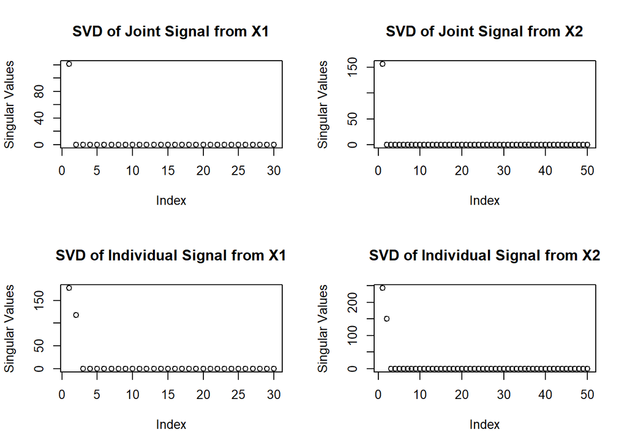

```r
true_signal_ranks = r.J + c(r.I1,r.I2)                          ##true ranks of overall signals
layout(matrix(1:4, nrow = 2))
ToyDat = GenerateToyData(n = n, p = c(p1, p2), JntVarEx = c(JntVarEx1, JntVarEx2),
                         IndVarEx = c(IndVarEx1, IndVarEx2), jnt_rank = r.J,
                         equal.eig = F, ind_rank = c(r.I1, r.I2), JntVarAdj = T, SVD.plots = T,
                         Error = T, print.cor = T, Loads = "Rademacher", Scores = "Gaussian")
```

```r
layout(1)
```

```r
blocks <- ToyDat[[2]]

##Setup input parameters to use Gavin's EM code
Y = do.call(cbind, blocks); P = c(p1, p2); Q = c(r.J,r.I1,r.I2)

# Theta
JntScores = ToyDat[['Scores']][['Joint']]
IndivScore.X1 = ToyDat[['Scores']][["Indiv"]][,c("Indiv X1 Score 1", "Indiv X1 Score 2")]
IndivScore.X2 = ToyDat[['Scores']][["Indiv"]][,c("Indiv X2 Score 1", "Indiv X2 Score 2")]

# WJ1 and WJ2
JntLd.X1 = t(ToyDat[['Loadings']][["Joint"]][[1]])
JntLd.X2 = t(ToyDat[['Loadings']][["Joint"]][[2]])

# WI1 and WI2
IndivLd.X1 = t(ToyDat[['Loadings']][["Indiv"]][[1]])
IndivLd.X2 = t(ToyDat[['Loadings']][["Indiv"]][[2]])
```

#### Empirical Variance Explained

Check that proportions of variance explained in the simulated data match the desired quantities. Empirical quantities of joint variance explained are $R_{J1}^2=$ 0.05 and $R_{J2}^2=$ 0.4992. For individual variance explained, empirical values are $R_{I1}^2=$ 0.2498 and $R_{I2}^2=$ 0.2496

# JIVE analyses

## ProJIVE

```r
##### ProJIVE
PJIVE.res = ProJIVE_EM(Y=Y, P=P, Q=Q, Max.iter=10000, diff.tol=1e-7, sig_hat = "MLE", init.loads = "AJIVE")
```

```
## [1] "Total Iteration = 6"
## [1] "Observed Data Likelihood = -164220.046994501"
## [1] "Complete Data Likelihood = -163509.20931841"
## [1] "Chordal Norm = 0.000309838650666375"
```

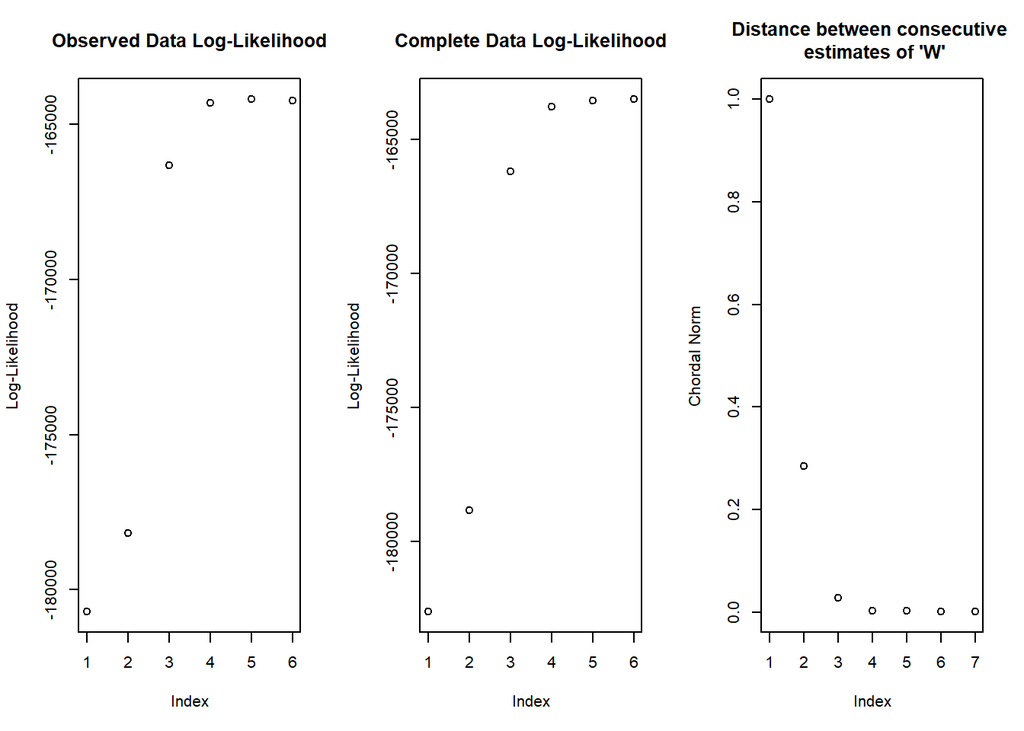

```r
PJIVE.scores = PJIVE.res$SubjectScoreMatrix
PJIVE.loads.X1 = PJIVE.res$LoadingMatrix[1:p1,-(sum(Q):(sum(Q[-3])+1))]
PJIVE.loads.X2 = PJIVE.res$LoadingMatrix[-(1:p1),-(r.J+1:r.I1)]
```

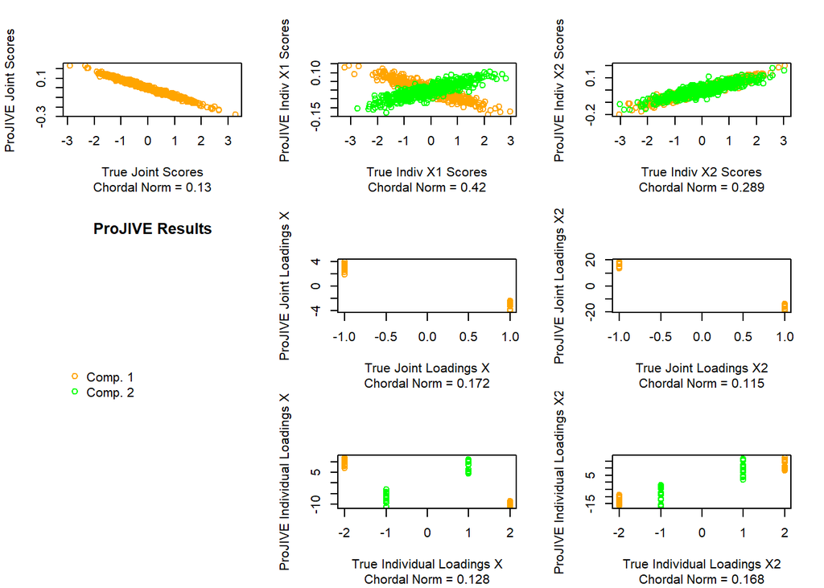

## CJIVE

Now, compute the CJIVE solution and graph subject scores and variable loadings.

```r
#### CJIVE
CJIVE.res = cc.jive(blocks, true_signal_ranks, r.J, perm.test = FALSE)

# CJIVE signal matrix estimates
J.hat = CJIVE.res$sJIVE$joint_matrices
I.hat = CJIVE.res$sJIVE$indiv_matrices

# CJIVE loading estimates
CJIVE.IndScores = lapply(I.hat, function(x) x[['u']])

# CJIVE loading estimates
WJ = lapply(J.hat, function(x) x[['v']])
WI = lapply(I.hat, function(x) x[['v']])
```

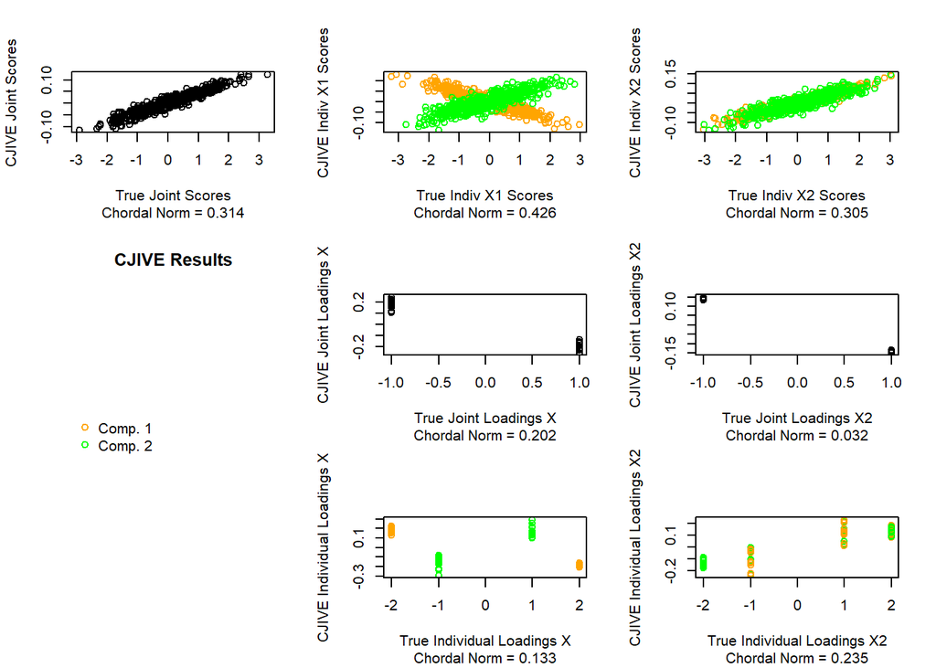

# Gaussian Mixture Scores: Toy data which do not correspond to the ProJIVE model

When study participants can be categorized due to an exogenous variable that is associated with the joint sources of variation (i.e. diagnosis categories, etc.), joint subject scores may be used to categorize participants. The code snippet here generates toy data that reflect this scenario by taking joint subject scores from Gaussian mixture model.

```
## [1] "Generating Scores from Gaussian_Mixture distributions and Loadings from Double_Exp distributions."
```

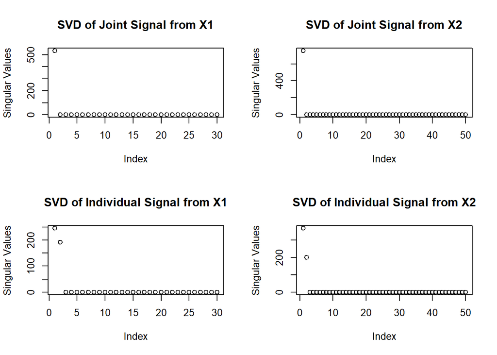

```r
true_signal_ranks = r.J + c(r.I1,r.I2)                          ##true ranks of overall signals
layout(matrix(1:4, nrow = 2))
ToyDat = GenerateToyData(n = n, p = c(p1, p2), JntVarEx = c(JntVarEx1, JntVarEx2),
                         IndVarEx = c(IndVarEx1, IndVarEx2), jnt_rank = r.J,
                         equal.eig = F, ind_rank = c(r.I1, r.I2), JntVarAdj = T, SVD.plots = T,
                         Error = T, print.cor = F, Loads = "Double_Exp", Scores = "Gaussian_Mixture")
```

```r
layout(1)
```

```r
blocks <- ToyDat[[2]]

##Setup input parameters to use Gavin's EM code
Y = do.call(cbind, blocks); P = c(p1, p2); Q = c(r.J,r.I1,r.I2)

# Theta
JntScores = ToyDat[['Scores']][['Joint']]
IndivScore.X1 = ToyDat[['Scores']][["Indiv"]][,c("Indiv X1 Score 1", "Indiv X1 Score 2")]
IndivScore.X2 = ToyDat[['Scores']][["Indiv"]][,c("Indiv X2 Score 1", "Indiv X2 Score 2")]

# WJ1 and WJ2
JntLd.X1 = t(ToyDat[['Loadings']][["Joint"]][[1]])
JntLd.X2 = t(ToyDat[['Loadings']][["Joint"]][[2]])

# WI1 and WI2
IndivLd.X1 = t(ToyDat[['Loadings']][["Indiv"]][[1]])
IndivLd.X2 = t(ToyDat[['Loadings']][["Indiv"]][[2]])
```

#### Empirical Variance Explained

Check that proportions of variance explained in the simulated data match the desired quantities. Empirical quantities of joint variance explained are $R_{J1}^2=$ 0.05 and $R_{J2}^2=$ 0.5036. For individual variance explained, empirical values are $R_{I1}^2=$ 0.25 and $R_{I2}^2=$ 0.2518

## CJIVE

Now, compute the CJIVE solution and graph subject scores and loadings.

```r
CJIVE.res = cc.jive(blocks, true_signal_ranks, r.J, perm.test = FALSE)

# CJIVE signal matrix estimates
J.hat = CJIVE.res$sJIVE$joint_matrices
I.hat = CJIVE.res$sJIVE$indiv_matrices

# CJIVE loading estimates
CJIVE.IndScores = lapply(I.hat, function(x) x[['u']])

# CJIVE loading estimates
WJ = lapply(J.hat, function(x) x[['v']])
WI = lapply(I.hat, function(x) x[['v']])
```

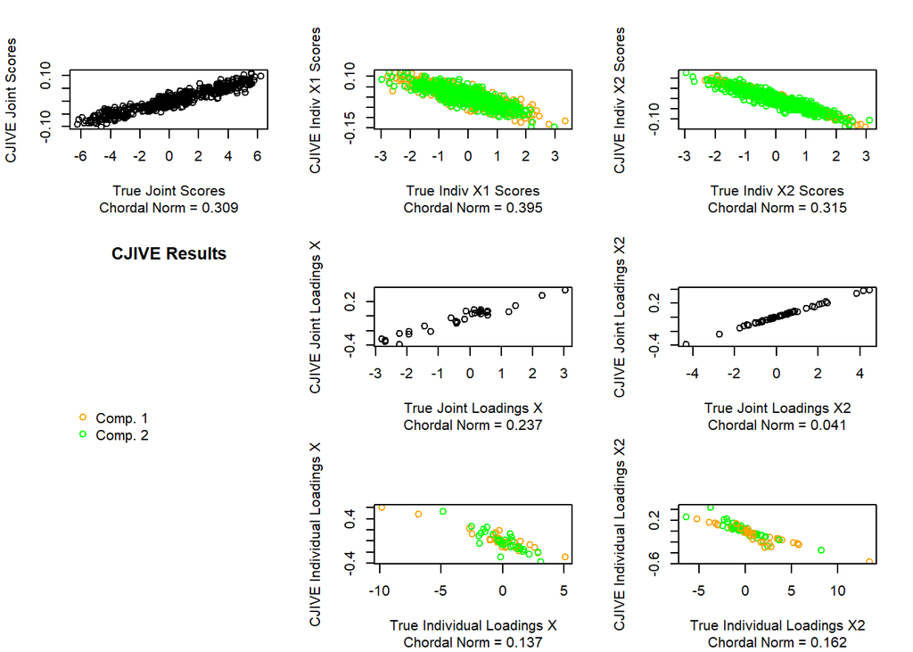

## ProJIVE

Now, compute the PJIVE solution and graph subject scores and loadings.

```r
##### ProJIVE
PJIVE.res = ProJIVE_EM(Y=Y, P=P, Q=Q, Max.iter=10000, diff.tol=1e-7, sig_hat = "MLE", init.loads = "AJIVE")
```

```
## [1] "Total Iteration = 6"
## [1] "Observed Data Likelihood = -164057.379766776"
## [1] "Complete Data Likelihood = -163424.194168934"
## [1] "Chordal Norm = 0.000199999994951361"
```

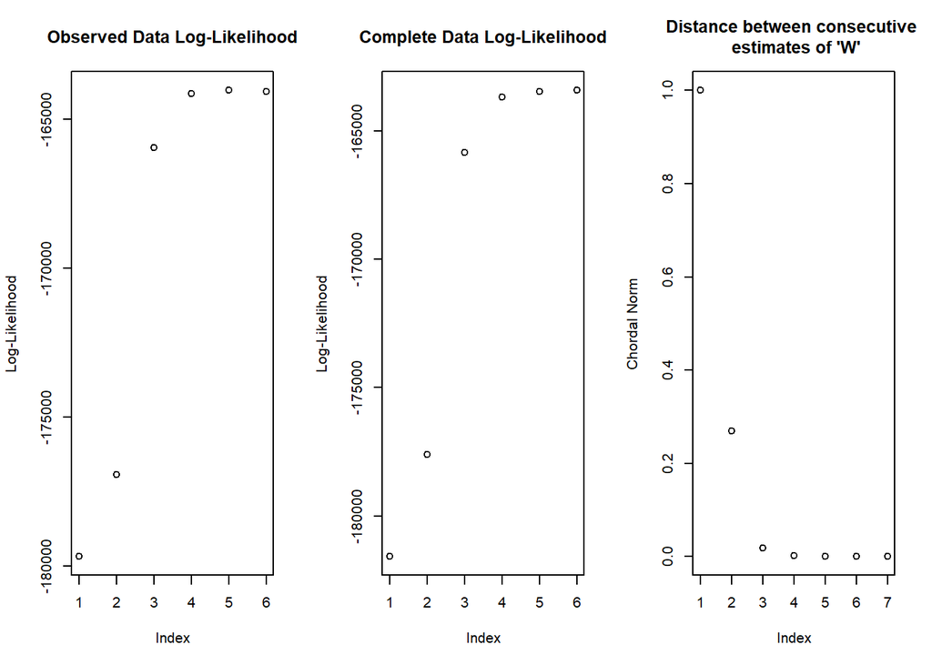

```r
PJIVE.scores = PJIVE.res$SubjectScoreMatrix
PJIVE.loads.X1 = PJIVE.res$LoadingMatrix[1:p1,-(sum(Q):(sum(Q[-3])+1))]
PJIVE.loads.X2 = PJIVE.res$LoadingMatrix[-(1:p1),-(r.J+1:r.I1)]
```

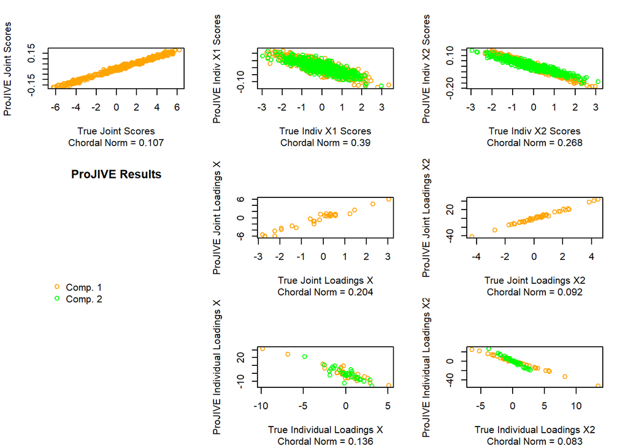

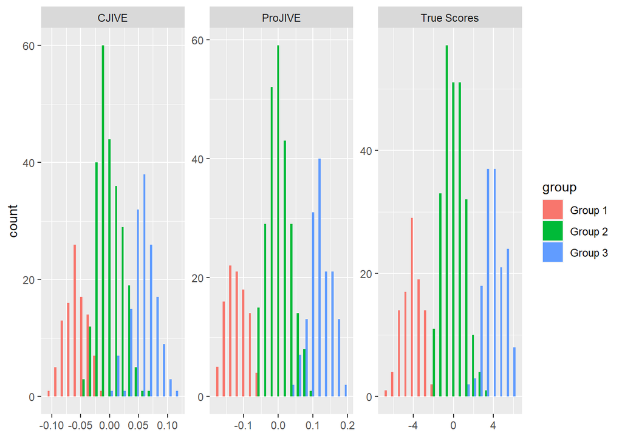

```r
## Proportions of groups for mixture
mix.probs = c(0.2, 0.5, 0.3)
n.mix = n*mix.probs
mix.group = factor(c(rep(1, n.mix[1]),rep(2, n.mix[2]),rep(3, n.mix[3])))
JntScores.dat = data.frame(V1 = c(CJIVE.res$CanCorRes$Jnt_Scores, PJIVE.scores[,1:r.J], JntScores))
JntScores.dat$group = factor(c(mix.group, mix.group, mix.group), labels = paste("Group", 1:3))
JntScores.dat$Method = factor(rep(1:3, each = n), labels = c("CJIVE", "ProJIVE", "True Scores"))
ggplot(data = JntScores.dat, aes(V1, fill = group)) + geom_histogram(bins = 20, position = "dodge") +
  facet_wrap(Method~., scales = "free") + labs(x = element_blank())
```